# City of Fort Collins Spending Analysis

I reside in Fort Collins, CO and had a desire to see what public information was available via public resources. The City of Fort Collins had an open data initiative which published spending data for 2014 & 2015.

The data was surprisingly clean and laid out in JSON format on Amazon S3. This post shows my exploration of the data along with some observations.

```r
source("cleaningData.R")
library(ggplot2)
library(lubridate)
library(dplyr)
library(scales)
```

I created a custom function to fetch, clean, and merge the data (code given at the end of this post).

The data is from [The City of Fort Collins Website](http://www.fcgov.com/opendata/)

```r
data = fetchAndCleanData()
data$year = year(data$gldate)
data$month = month(data$gldate,label=TRUE)
data$day = day(data$gldate)
data$dayOfWeek = wday(data$gldate,label=TRUE)
```

### When are vendors being paid by the City of Fort Collins?

- The overwhelming majority of payments are made at the end of the month *Fig. 1 & 2*
- This is not affected by the year or the month *Fig. 1 & 2*
- In January and February, between 15-20% of the payments were on the final day of the month *Fig. 2*
- Almost all payments are made during the week (no surprise there) *Fig. 3*
- Strangely, Thursday seems to have fewer payments than other days
- It is substantially lower than other days in both years
- However, there is a relatively simple explanation: the end of the month happened either on those days, or that was the final day before the weekend
- For example, Friday would have been the final business day of the month in 6 out of 12 months of 2014

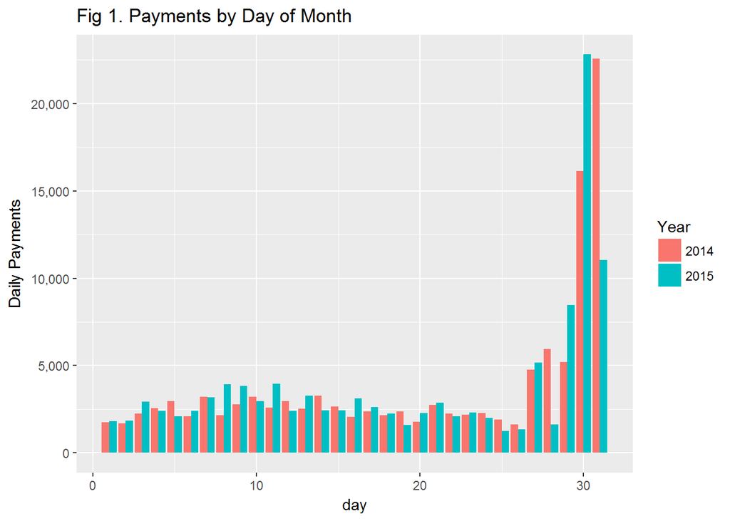

```r
p = ggplot(data, aes(day, fill = factor(year)))

p + geom_bar(position='dodge') +
  scale_y_continuous(name="Daily Payments",
                     labels = comma) +
  ggtitle('Fig 1. Payments by Day of Month') +
  scale_fill_discrete(name = "Year")
```

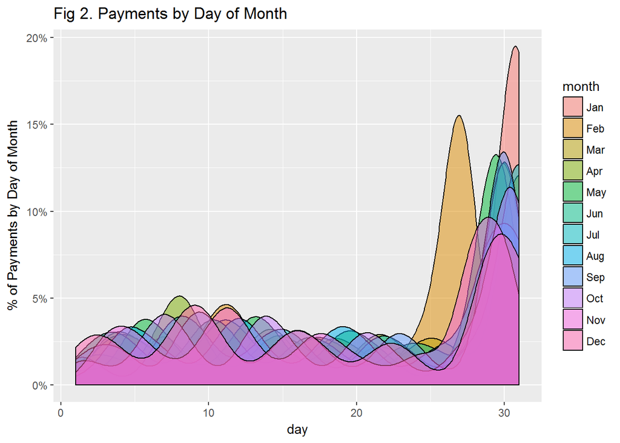

```r
p = ggplot(data, aes(day, fill = month))
p + geom_density(alpha = 0.5) +
  scale_y_continuous(name="% of Payments by Day of Month",
                     labels = percent) +
  ggtitle('Fig 2. Payments by Day of Month')
```

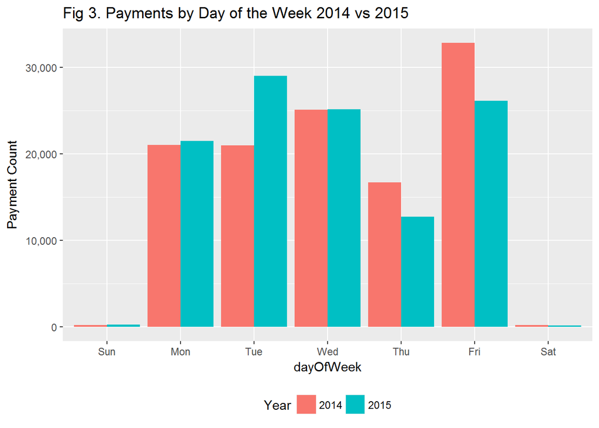

```r
p = ggplot(data, aes(dayOfWeek,fill=factor(year)))
p + geom_bar(position='dodge') +
  scale_y_continuous(name="Payment Count",
                     labels = comma) +
  scale_fill_discrete(name = "Year") +
  ggtitle('Fig 3. Payments by Day of the Week 2014 vs 2015') +
  theme(legend.position='bottom')
```

## What Departments Spent the Most?

```r
df = data %>%
  group_by(year,DEPTNAME) %>%
  summarise(payments = sum(glamount)) %>%
  arrange(desc(payments)) %>%
  top_n(10)
```

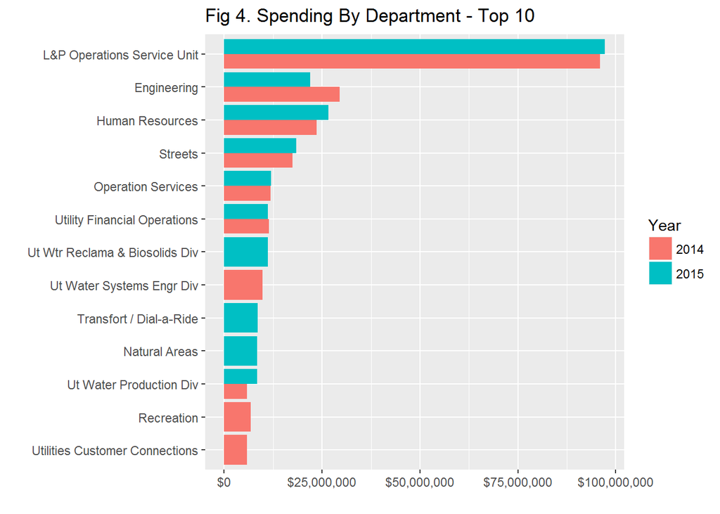

```r
p = ggplot(df,aes(x=reorder(DEPTNAME,payments),y=payments,fill=factor(year)))
p + geom_bar(stat='identity',position='dodge') +
  labs(title='Fig 4. Spending By Department - Top 10',x='') +
  scale_y_continuous(name="",
                     labels = dollar) +
  scale_fill_discrete(name = "Year") +
  coord_flip()
```

## What was L&P Operations Service Unit spending so much money on?

- Almost all of the money goes to Platte River Power Authority
- This makes a lot of sense, afterall, L&P stands for Light & Power!
- After removing this outlier, the rest of the data is easier to visualize
- The most interesting observation: “fountain, city of” cost over $1.25M!

```r
df = data %>%
  filter(DEPTNAME == 'L&P Operations Service Unit') %>%
  group_by(year,glvendor) %>%
  summarise(payments = sum(glamount)) %>%
  arrange(desc(payments)) %>%
  top_n(10)
```

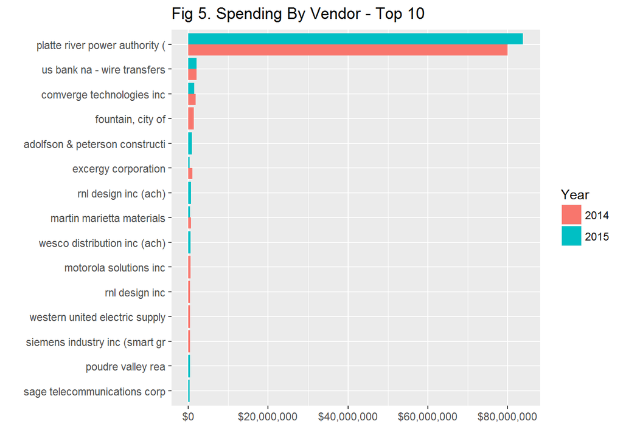

```r
p = ggplot(df,aes(x=reorder(glvendor,payments),y=payments,fill=factor(year)))
p + geom_bar(stat='identity',position='dodge') +
  labs(title='Fig 5. Spending By Vendor - Top 10',x='') +
  scale_y_continuous(name="",
                     labels = dollar) +
  scale_fill_discrete(name = "Year") + coord_flip()
```

```r
df = data %>%
  filter(DEPTNAME == 'L&P Operations Service Unit') %>%
  filter(glvendor != 'platte river power authority (') %>%
  group_by(year,glvendor) %>%
  summarise(payments = sum(glamount)) %>%
  arrange(desc(payments)) %>%
  top_n(10)
```

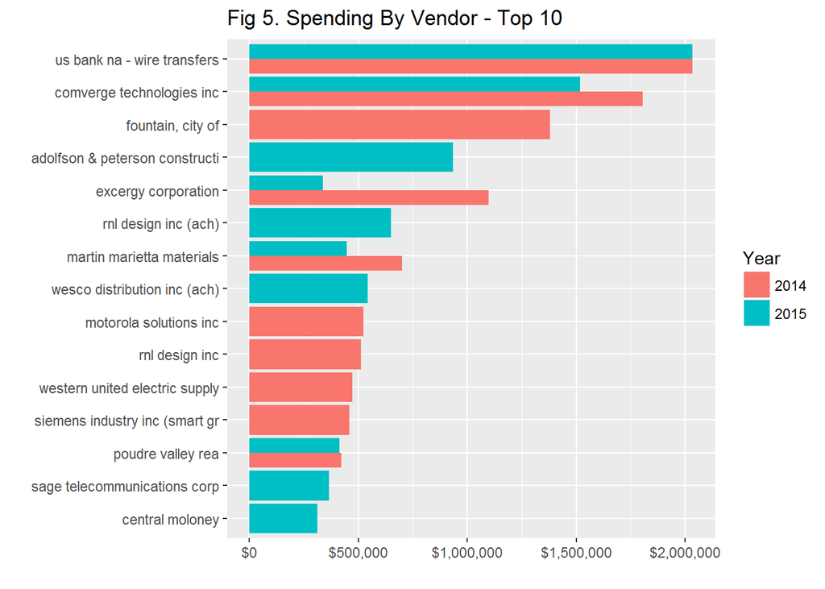

```r
p = ggplot(df,aes(x=reorder(glvendor,payments),y=payments,fill=factor(year)))
p + geom_bar(stat='identity',position='dodge') +
  labs(title='Fig 5. Spending By Vendor - Top 10',x='') +
  scale_y_continuous(name="",
                     labels = dollar) +
  scale_fill_discrete(name = "Year") + coord_flip()
```

## Which vendors received the highest average payments?

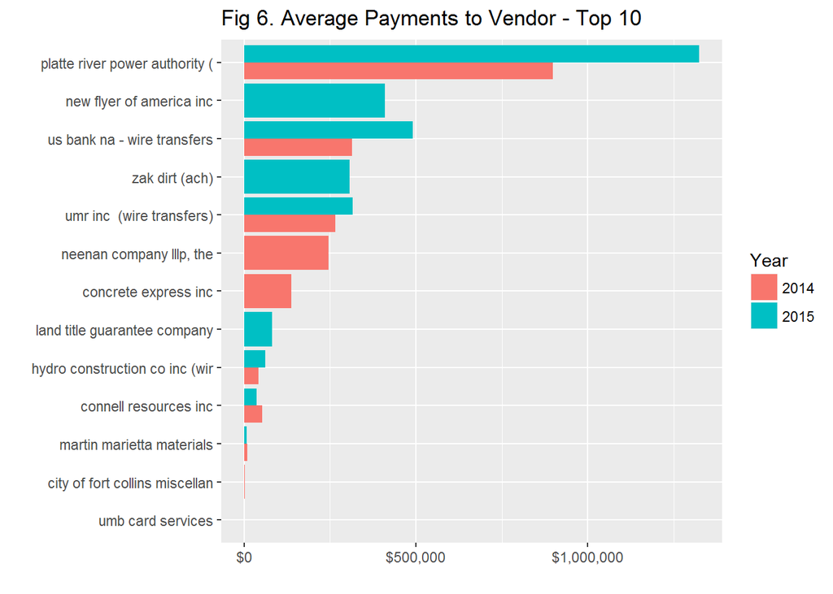

```r
vendorSummary = data %>% group_by(year,glvendor) %>%
  summarize(
    payments = sum(glamount),
    count = length(glvendor),
    averagePayment =
      round(sum(glamount)/ length(glvendor),2)) %>%
  arrange(desc(averagePayment))

vendorTop10 = top_n(vendorSummary, 10, payments)

p = ggplot(vendorTop10,
           aes(x=reorder(glvendor,averagePayment),
               y=averagePayment,fill=factor(year)))
p + geom_bar(stat='identity',position='dodge') +
  coord_flip() +
  labs(title='Fig 6. Average Payments to Vendor - Top 10',x='') +
  scale_y_continuous(name="",
                     labels = dollar) +
  scale_fill_discrete(name = "Year") + coord_flip()
```

After diving into a few different departments and finding relatively unremarkable things I finally stumbled across ‘Patrol’ and it piqued my interest.

## What vendors had the highest payments in the ‘Patrol’ department?

- Redflex Traffic Systems Inc. was the number one vendor
- This is a maker of red light cameras
- There is a lot of controversy around this company and red light cameras in general
- The company’s former CEO resigned due to being tied to bribes paid to elected officials
- Chicago and Columbus were the cities in which bribery was being conducted - [News Article](http://abc7chicago.com/news/redflex-helps-feds-avoids-charges-in-red-light-camera-scandal/1676187/)
- The financial return on these cameras is constantly being scrutinized in the US - [News Article](http://www.coloradoan.com/story/news/2015/02/28/colorado-debate-red-light-speed-cameras-worth/24209831/) - the costs associated with the cameras are relatively high
- Chicago (among others) are questioning how effective these cameras are at reducing accidents [News Article](http://www.chicagotribune.com/ct-red-light-camera-safety-met-20141219-story.html#page=1)

```r
df = data %>%
  filter(DEPTNAME == 'Patrol') %>%
  group_by(glvendor) %>%
  summarise(payments = sum(glamount)) %>%
  arrange(desc(payments)) %>%
  top_n(20)
```

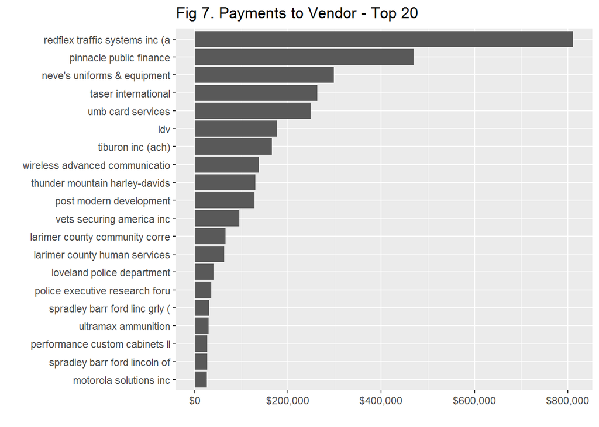

```r
p = ggplot(df,aes(x=reorder(glvendor,payments),y=payments))
p + geom_bar(stat='identity') +
  labs(title='Fig 7. Payments to Vendor - Top 20',x='') +
  scale_y_continuous(name="",
                     labels = dollar) +
  coord_flip()
```

## Conclusion

- Overall, spending appears to align with what we see in Fort Collins
- It will be interesting to see if Redflex continues to be on the payroll after what happened in Chicago & Columbus (not to mention the ROI and efficacy studies)
- There’s not enough data to see a trend or attempt to make a forecast for future spending
- Spending on schools and education has been a big topic in Fort Collins, I’ll attempt to find changes in this as we move forward and the data is updated

Code used in this post is on my [GitHub](https://github.com/stoltzmaniac/cityOfFortCollinsPayees)